# Part II - Explanatory Slide Deck (Outcome)

## Communicating Data Findings on Prosper Loan Data Exploration and Visualization

## By Ayomide (Enoch) Fadeyi

## Investigation Overview

## General Research Question guiding my analysis

### What are the main driving factors of outcome of loan?

> In part one of this project, the above question and a host of others have been answered during the exploratory data analysis stage. However, in this part two, I intend to carry out explanatory data analysis, explaining my findings using visuals and interpretation of these visuals. I will be adding a summary of key insights as contained in the README.md. This will helps my notebook to stay aligned to the key insights I want to include in my slide deck.

## Key Insights for Presentation

*** Those with low prosper rating are found to have highest rates of default in credits.

## Dataset Overview

## Introduction

> Introducing my dataset *** Loan Data from Prosper: This data set contains 113,937 observations (loans) with 81 features (variables/columns) on each loan, including loan amount, borrower rate (or interest rate), current loan status, borrower income, and many others. Here is the link to the data dictionary to understand the dataset's variables: https://docs.google.com/spreadsheets/d/1gDyi_L4UvIrLTEC6Wri5nbaMmkGmLQBk-Yx3z0XDEtI/edit#gid=0

### Visualization 1

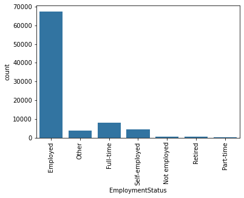

### Observation 2

As seen in the below visual, there is a significant difference between the completed Loan and defaulted Loan of employed and unemployed. The employed tend to complete their loans than the unemployed

### Visualization 2

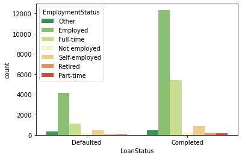

### Visualization 3

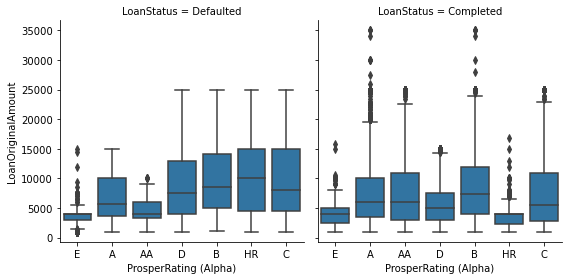

### Observation 4

1. Business listing category have larger amount of completed loans.
2. Home improvement have larger amount of defauled loans.

# Visualization 4

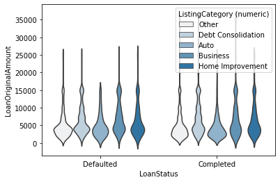

[output not shown]

[output not shown]

[output not shown]

[output cut: 123 more lines]

[output not shown]

[output not shown]